# Reproducible Research: Peer Assessment 1

## Loading and preprocessing the data

**Load the data**

```r
data <- read.csv('activity.csv')
```

**Process/transform the data**

```r
data$date <- as.Date(data$date, '%Y-%m-%d')
```

## What is mean total number of steps taken per day?

**Calculate the total number of step taken per day**

```r
stepsByDay <- aggregate(data$steps, by=list(data$date), FUN=sum, na.rm=TRUE)
```

**Make a histogram of the total number of steps taken each day**

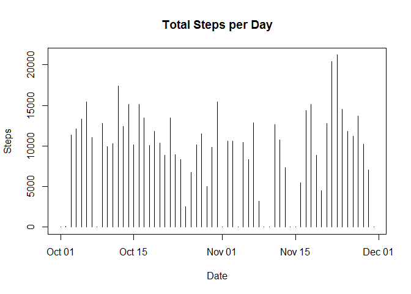

```r
plot(stepsByDay, type='h', main='Total Steps per Day', ylab='Steps', xlab='Date')
```

**Calculate and report the mean and median of total number of steps taken per day**

```r
theMean <- mean(stepsByDay$x)
theMedian <- median(stepsByDay$x)
theMean
```

```
## [1] 9354.23
```

```r
theMedian
```

```
## [1] 10395
```

## What is the average daily activity pattern?

**Average number of steps taken across all days**

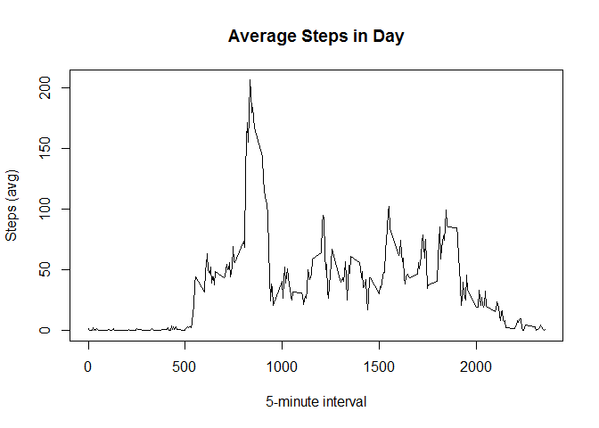

```r
stepsAvg <- aggregate(data$steps, by=list(data$interval), FUN=mean, na.rm=TRUE)
plot(stepsAvg, type='l', main='Average Steps in Day', ylab='Steps (avg)', xlab='5-minute interval')
```

**Which 5-minute interval contains the maximum number of steps?**

```r
stepsAvg[which.max(stepsAvg$x),1]
```

```
## [1] 835
```

## Imputing missing values

**Total number of missing values**

```r
nrow(data[is.na(data$steps),])
```

```
## [1] 2304
```

**Strategy for filling in all of the missing values**

Replaces NAs with the 5-minute average, we need to repeat the 5-minute average by the number of days in data set

```r
nDays = length(unique(data$date))
means = rep(stepsAvg$x, nDays)
NAs = is.na(data$steps)
```

**Create a new dataset with the missing data filled in**

```r
data.noNA <- data
data.noNA[NAs,]$steps <- means[NAs]
```

**Histogram of the total number of steps, mean and median total number of steps taken per day**

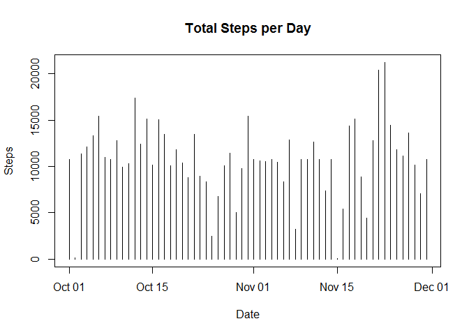

```r
stepsByDay.noNA <- aggregate(data.noNA$steps, by=list(data.noNA$date), FUN=sum)
plot(stepsByDay.noNA, type='h', main='Total Steps per Day', ylab='Steps', xlab='Date')
```

```r
theMean.noNA <- mean(stepsByDay.noNA$x)
theMedian.noNA <- median(stepsByDay.noNA$x)
theMean.noNA
```

```
## [1] 10766.19
```

```r
theMedian.noNA
```

```
## [1] 10766.19
```

The results with missing values filled differ from previous estimates.

## Are there differences in activity patterns between weekdays and weekends?

**Create a new factor variable with two levels (weekday and weekend)**

```r
days <- weekdays(data.noNA$date)
classifDays <- rep(1, length(days))
classifDays[days == 'Saturday' | days == 'Sunday'] <- 2
factorDays <- factor(classifDays, levels=c(1,2), labels=c('weekday', 'weekend'))
data.noNA$day.type <- factorDays
```

**Panel plot of average steps in 5-minute interval by weekdays and weekends**

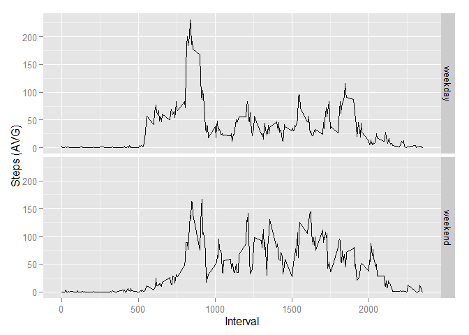

```r
library(ggplot2)
stepsAvgDays <- with(data.noNA, aggregate(steps ~ interval + day.type, FUN=mean))
qplot(interval, steps, geom='line', data=stepsAvgDays) + facet_grid(day.type ~ .) + ylab('Steps (AVG)') + xlab('Interval')
```